# Portfolio Update

# Performance 🏄

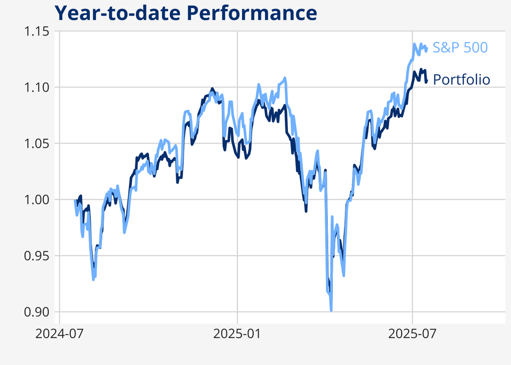

- **Beta** measures the sensitivity of an investment’s returns to movements in the broader market, indicating its level of market-related risk. A beta above 1 suggests higher volatility than the market, while a beta below 1 indicates lower volatility.
- Your portfolio’s all-time beta of 1.05 indicates that it is more volatile than the market. This means it generally moves more dramatically in response to market changes.

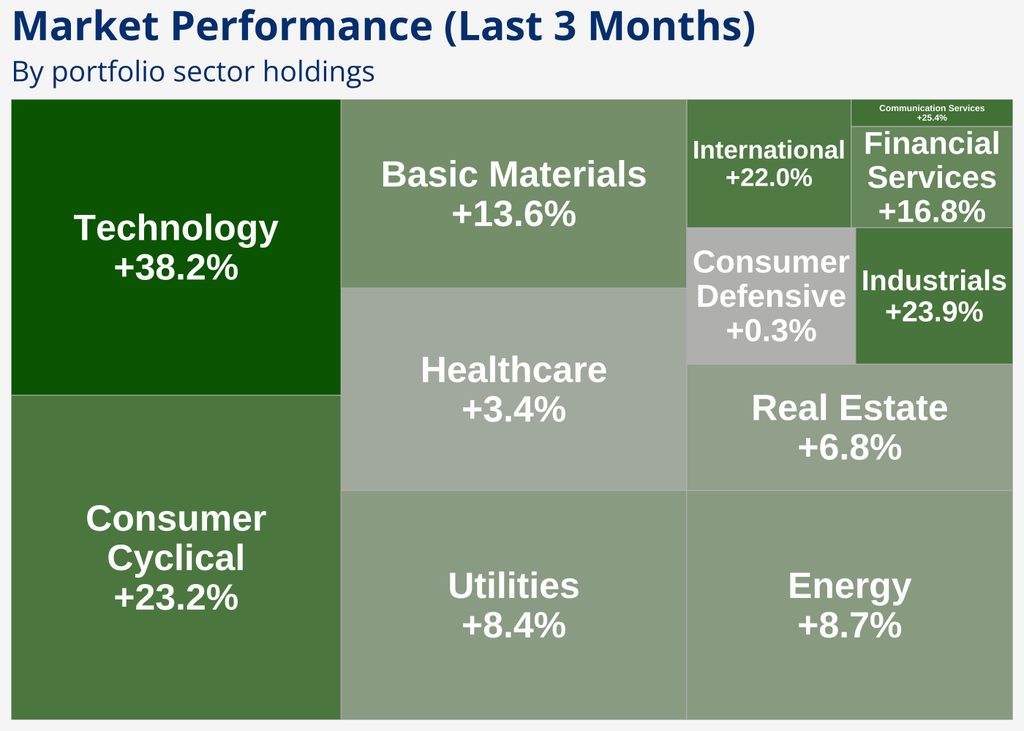

# Risk 📊

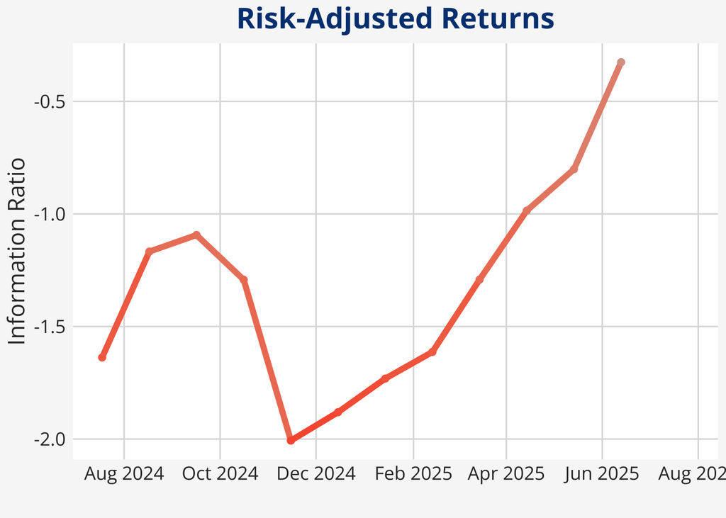

- **The Information Ratio** measures how much excess return an investment generates compared to its benchmark, relative to the amount of risk taken. It essentially quantifies your ability to consistently outperform the market.
- Your portfolio currently has a year-to-date Information Ratio of -0.33 using the S&P 500 as a benchmark. Negative Information Ratio values generally indicate inferior risk-adjusted performance. An IR of -0.33 signifies the portfolio generated 0.33 units of return less per unit of risk compared to the benchmark.

## Contributions to Risk

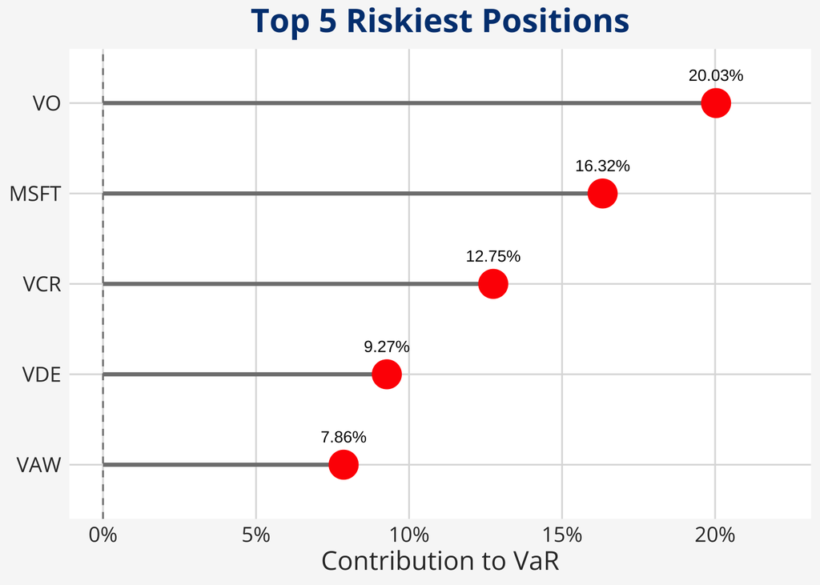

- **Value at Risk (VaR)** is a financial metric that estimates the maximum potential loss an investment might face over a specific time period, given a certain confidence level. In simpler terms, it’s a way to gauge how much you could lose on a particularly rough day in the market, helping you prepare for financial stormy weather.
- A VaR percent contribution of 20% for VO means that this particular stock is responsible for about 20% of your portfolio’s total risk, as measured by Value at Risk. In other words, if you were to experience a loss at your calculated VaR level, approximately 20% of that loss would be attributable to VO.

## Diversification

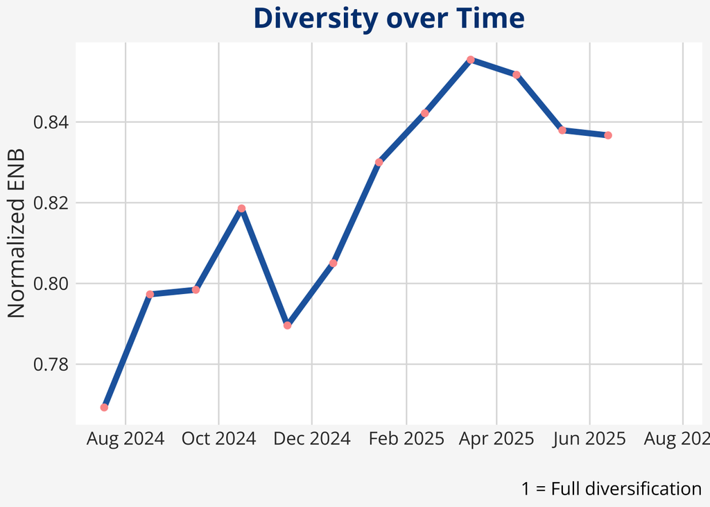

- The **normalized effective number of bets (ENB)** is a measure of portfolio diversity that quantifies how evenly a portfolio’s investments are spread across different assets. It indicates the effective number of independent bets within the portfolio, with higher values representing greater diversification and lower values indicating concentration in fewer assets
- The portfolio is moderately diversified with an ENB of 0.83, meaning its investments are spread out, but there is still some concentration. The portfolio is somewhat reliant on a smaller group of key investments, though it remains more spread out than concentrated.

### **Contributions to Diversification**

| Low Correlation Assets | High Correlation Assets |
| --- | --- |
| 1. VGLT | 1. TSLA |
| 2. VO | 2. VAW |
| 3. VYMI | 3. VB |
| 4. VCR | 4. VCLT |
| 5. VTMGX | 5. VGK |

- Low Correlation Assets: These assets move independently from the rest of the portfolio, providing unique sources of return and risk. They enhance diversification by behaving differently from other holdings during various market conditions. Including these assets can potentially improve the portfolio’s risk-adjusted returns and stability.
- High Correlation Assets: These securities tend to move in sync with other holdings in the portfolio. They offer less diversification benefit as their performance is closely tied to existing positions. While they may still be valuable for other reasons (e.g., high expected returns), they contribute less to reducing overall portfolio risk through diversification.

# Targets 🎯

## By asset class

| Asset Class | Target Weight | Weight v. Target | Difference from Target |
| --- | --- | --- | --- |
| Equity | 85.0% |  | 11.5% |
| Fixed Income | 15.0% |  | −11.5% |

As of the latest update, your portfolio consists of 96.5% Equity assets, totaling $43,836.26, and 3.5% Fixed Income assets, totaling $1,585.65.

## By sector

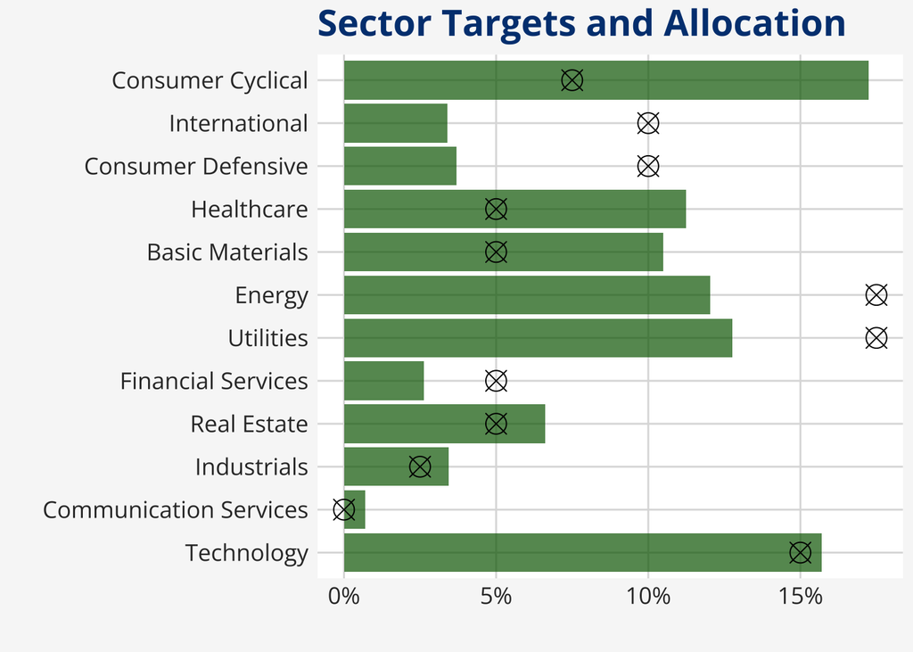

- Looks like someone’s been indulging! The top over-invested sectors compared to their targets are: Consumer Cyclical, Healthcare, Basic Materials. Time to trim the fat?
- Playing it safe, huh? The top under-invested sectors compared to their targets are: International, Consumer Defensive, Energy. Maybe give them a little more love?

# Reinvestment 💰

Given $4000 to invest (split over 2 months) how much should be allocated to each asset security to best align with your goals?

[output not shown]

**Note**

Allocation is computed by:

1. Bond-Equity Weights
2. Equity Sector Weights
3. Contribution to Diversification

# Taxes 💸

To off set your gains from your sales, consider selling some of your positions that have lost money

Portfolio Loss Analysis

Stocks with the Largest Losses

|  | Stock | Avg. Cost Basis | Current Price | Total Shares | Total Loss |
| --- | --- | --- | --- | --- | --- |
|  | AMZN | 3,147.08 | 223.19 | 5 | −$14,619.44 |
|  | SHOP | 1,242.40 | 120.00 | 6 | −$6,734.39 |
|  | WMT | 142.07 | 95.15 | 19 | −$874.06 |
|  | TSLA | 600.42 | 321.67 | 1 | −$278.75 |
|  | VDE | 127.26 | 120.76 | 30 | −$196.32 |
|  | VHT | 260.76 | 247.58 | 12 | −$160.57 |
|  | VGLT | 56.19 | 54.31 | 12 | −$23.50 |
|  | VCLT | 75.42 | 73.99 | 12 | −$16.77 |
|  | VNQ | 90.26 | 89.85 | 19 | −$7.62 |
| TOTAL | — | — | — | — | -22911.41 |

# Current Portfolio

Portfolio Performance Analysis

Profit/Loss by Position

| Security | Avg Cost | Current Price | Shares | Profit/Loss | Return % |
| --- | --- | --- | --- | --- | --- |
| MSFT | $245.05 | $505.62 | 14.53 | $3,786.09 | 106.3% |
| VCR | $269.34 | $365.87 | 11.47 | $1,106.96 | 35.8% |
| VAW | $160.72 | $197.97 | 16.75 | $623.82 | 23.2% |
| VB | $200.25 | $240.76 | 7.65 | $310.04 | 20.2% |
| VTMGX | $15.47 | $18.16 | 2.02 | $5.42 | 17.4% |
| VO | $248.62 | $280.88 | 31.67 | $1,021.84 | 13.0% |
| VWO | $45.48 | $50.24 | 14.08 | $67.07 | 10.5% |
| VGK | $71.17 | $77.19 | 1.00 | $6.02 | 8.5% |
| VYMI | $74.58 | $80.18 | 1.00 | $5.60 | 7.5% |
| VPU | $168.12 | $177.29 | 21.15 | $193.86 | 5.5% |
| VPL | $77.34 | $80.94 | 16.56 | $59.66 | 4.7% |
| VNQ | $90.26 | $89.85 | 18.80 | −$7.62 | −0.4% |
| VCLT | $75.42 | $73.99 | 11.76 | −$16.77 | −1.9% |
| VGLT | $56.19 | $54.31 | 12.50 | −$23.50 | −3.3% |
| VHT | $260.76 | $247.58 | 12.18 | −$160.57 | −5.1% |
| VDE | $127.26 | $120.76 | 30.22 | −$196.32 | −5.1% |
| WMT | $142.07 | $95.15 | 18.63 | −$874.06 | −33.0% |
| TSLA | $600.42 | $321.67 | 1.00 | −$278.75 | −46.4% |
| SHOP | $1,242.40 | $120.00 | 6.00 | −$6,734.39 | −90.3% |
| AMZN | $3,147.08 | $223.19 | 5.00 | −$14,619.44 | −92.9% |

| name | weights | sector | asset | value |
| --- | --- | --- | --- | --- |
| VO | 19.6% | Mid-cap Index | Equity | $8,896.03 |
| MSFT | 16.2% | Technology | Equity | $7,346.66 |
| VCR | 9.2% | Consumer Cyclical | Equity | $4,195.80 |
| VPU | 8.3% | Utilities | Equity | $3,749.86 |
| VDE | 8.0% | Energy | Equity | $3,649.85 |
| VAW | 7.3% | Basic Materials | Equity | $3,315.60 |
| VHT | 6.6% | Healthcare | Equity | $3,015.52 |
| VB | 4.1% | Small-cap Index | Equity | $1,842.78 |
| WMT | 3.9% | Consumer Defensive | Equity | $1,772.45 |
| VNQ | 3.7% | Real Estate | Equity | $1,689.09 |
| VPL | 3.0% | International | Equity | $1,340.45 |
| AMZN | 2.5% | Consumer Cyclical | Equity | $1,115.95 |
| VCLT | 1.9% | Long-Term Bond | Fixed Income | $870.27 |
| SHOP | 1.6% | Technology | Equity | $720.00 |
| VWO | 1.6% | International | Equity | $707.18 |
| VGLT | 1.5% | Long Government | Fixed Income | $678.77 |
| TSLA | 0.7% | Consumer Cyclical | Equity | $321.67 |
| VYMI | 0.2% | International | Equity | $80.18 |
| VGK | 0.2% | International | Equity | $77.19 |
| VTMGX | 0.1% | Foreign Large Blend | Fixed Income | $36.61 |